# Notebook

```python
import pandas as pd
import numpy as np
import scipy.stats
import sklearn.linear_model
#import pandasql as psql
#import pylab as pl
#import matplotlib as mpl
import matplotlib.pyplot as plt
from ggplot import *
import seaborn as sns

%matplotlib inline

sns.set_palette("deep", desat = .6)
sns.set_context(rc={"figure.figsize":(12,8)})

pd.set_option('display.max_columns',100)
```

REFERENCES

pandas.pydata.org

stanford.edu/~mwaskom/software/seaborn/

http://blog.yhathq.com/posts/R-and-pandas-and-what-ive-learned-about-each.html

https://github.com/justmarkham/scikit-learn-videos

http://scikit-learn.org/stable/modules/generated/sklearn.linear_model.LinearRegression.html

The purpose of this project is to assess whether more individuals ride the subway when it rains and to generate a linear model to predict the number of hourly entries given the features provided in the dataset.

After reading in the data from the provided csv file, we quickly inspect the data to determine the size of the data frame, specifically the number of entries as well as the provided information for each data point. For our initial analysis, we will only require two columns, the first corresponding the the entries hourly, and the second corresponding the the indicator variable, rain, which takes on values 0 and 1. A first pass assessment of the data indicates that approximately 78% of the data comes from entries where there is no rain.

For our analysis of we first look at the distribution of the data independent of rain. Because we are specifically interested in whether or not more individuals ride when it rains, we can utilize a one-sized test at a significance level of .05. To determine the appropriate test to use, we can plot the data as a histogram. Because the distribution is not normal, we choose to use a non-parametric test, specifically the Mann-Whitney U.

```python
subway = pd.read_csv('../IntroToDataScience/improved-dataset/turnstile_weather_v2.csv')
subway.shape
```

```
(42649, 27)
```

```python
subway.columns
```

```
Index([u'UNIT', u'DATEn', u'TIMEn', u'ENTRIESn', u'EXITSn', u'ENTRIESn_hourly',
       u'EXITSn_hourly', u'datetime', u'hour', u'day_week', u'weekday',
       u'station', u'latitude', u'longitude', u'conds', u'fog', u'precipi',
       u'pressurei', u'rain', u'tempi', u'wspdi', u'meanprecipi',
       u'meanpressurei', u'meantempi', u'meanwspdi', u'weather_lat',
       u'weather_lon'],
      dtype='object')
```

```python
subway.head()
```

|  | UNIT | DATEn | TIMEn | ENTRIESn | EXITSn | ENTRIESn_hourly | EXITSn_hourly | datetime | hour | day_week | weekday | station | latitude | longitude | conds | fog | precipi | pressurei | rain | tempi | wspdi | meanprecipi | meanpressurei | meantempi | meanwspdi | weather_lat | weather_lon |
| --- | --- | --- | --- | --- | --- | --- | --- | --- | --- | --- | --- | --- | --- | --- | --- | --- | --- | --- | --- | --- | --- | --- | --- | --- | --- | --- | --- |
| 0 | R003 | 05-01-11 | 00:00:00 | 4388333 | 2911002 | 0 | 0 | 2011-05-01 00:00:00 | 0 | 6 | 0 | CYPRESS HILLS | 40.689945 | -73.872564 | Clear | 0 | 0 | 30.22 | 0 | 55.9 | 3.5 | 0 | 30.258 | 55.98 | 7.86 | 40.700348 | -73.887177 |
| 1 | R003 | 05-01-11 | 04:00:00 | 4388333 | 2911002 | 0 | 0 | 2011-05-01 04:00:00 | 4 | 6 | 0 | CYPRESS HILLS | 40.689945 | -73.872564 | Partly Cloudy | 0 | 0 | 30.25 | 0 | 52.0 | 3.5 | 0 | 30.258 | 55.98 | 7.86 | 40.700348 | -73.887177 |
| 2 | R003 | 05-01-11 | 12:00:00 | 4388333 | 2911002 | 0 | 0 | 2011-05-01 12:00:00 | 12 | 6 | 0 | CYPRESS HILLS | 40.689945 | -73.872564 | Mostly Cloudy | 0 | 0 | 30.28 | 0 | 62.1 | 6.9 | 0 | 30.258 | 55.98 | 7.86 | 40.700348 | -73.887177 |
| 3 | R003 | 05-01-11 | 16:00:00 | 4388333 | 2911002 | 0 | 0 | 2011-05-01 16:00:00 | 16 | 6 | 0 | CYPRESS HILLS | 40.689945 | -73.872564 | Mostly Cloudy | 0 | 0 | 30.26 | 0 | 57.9 | 15.0 | 0 | 30.258 | 55.98 | 7.86 | 40.700348 | -73.887177 |
| 4 | R003 | 05-01-11 | 20:00:00 | 4388333 | 2911002 | 0 | 0 | 2011-05-01 20:00:00 | 20 | 6 | 0 | CYPRESS HILLS | 40.689945 | -73.872564 | Mostly Cloudy | 0 | 0 | 30.28 | 0 | 52.0 | 10.4 | 0 | 30.258 | 55.98 | 7.86 | 40.700348 | -73.887177 |

```python
subway.dtypes
```

```
UNIT                object
DATEn               object
TIMEn               object
ENTRIESn             int64
EXITSn               int64
ENTRIESn_hourly    float64
EXITSn_hourly      float64
datetime            object
hour                 int64
day_week             int64
weekday              int64
station             object
latitude           float64
longitude          float64
conds               object
fog                  int64
precipi            float64
pressurei          float64
rain                 int64
tempi              float64
wspdi              float64
meanprecipi        float64
meanpressurei      float64
meantempi          float64
meanwspdi          float64
weather_lat        float64
weather_lon        float64
dtype: object
```

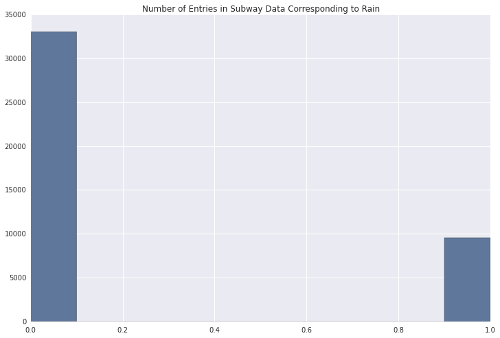

```python
subway.rain.hist()
plt.title('Number of Entries in Subway Data Corresponding to Rain')
```

```python
subway.groupby(['rain']).aggregate(np.mean)
```

| rain | ENTRIESn | EXITSn | ENTRIESn_hourly | EXITSn_hourly | hour | day_week | weekday | latitude | longitude | fog | precipi | pressurei | tempi | wspdi | meanprecipi | meanpressurei | meantempi | meanwspdi | weather_lat | weather_lon |
| --- | --- | --- | --- | --- | --- | --- | --- | --- | --- | --- | --- | --- | --- | --- | --- | --- | --- | --- | --- | --- |
| 0 | 28158345.474050 | 19906411.104767 | 1845.539439 | 1333.111451 | 10.049359 | 2.998064 | 0.682616 | 40.724497 | -73.940368 | 0.002147 | 0.000008 | 29.997082 | 64.304694 | 6.561112 | 0.000008 | 29.997082 | 64.304694 | 6.561112 | 40.728433 | -73.938697 |
| 1 | 28009333.335107 | 19744097.584351 | 2028.196035 | 1459.373918 | 10.037767 | 2.587167 | 0.824204 | 40.725167 | -73.940349 | 0.036307 | 0.020520 | 29.881459 | 58.961158 | 8.193031 | 0.020520 | 29.881459 | 58.961158 | 8.193031 | 40.728978 | -73.938680 |

```python
subway.groupby(['rain']).describe()
```

| rain |  | ENTRIESn | ENTRIESn_hourly | EXITSn | EXITSn_hourly | day_week | fog | hour | latitude | longitude | meanprecipi | meanpressurei | meantempi | meanwspdi | precipi | pressurei | tempi | weather_lat | weather_lon | weekday | wspdi |
| --- | --- | --- | --- | --- | --- | --- | --- | --- | --- | --- | --- | --- | --- | --- | --- | --- | --- | --- | --- | --- | --- |
| 0 | count | 3.306400e+04 | 33064.000000 | 3.306400e+04 | 33064.000000 | 33064.000000 | 33064.000000 | 33064.000000 | 33064.000000 | 33064.000000 | 33064.000000 | 33064.000000 | 33064.000000 | 33064.000000 | 33064.000000 | 33064.000000 | 33064.000000 | 33064.000000 | 33064.000000 | 33064.000000 | 33064.000000 |
|  | mean | 2.815835e+07 | 1845.539439 | 1.990641e+07 | 1333.111451 | 2.998064 | 0.002147 | 10.049359 | 40.724497 | -73.940368 | 0.000008 | 29.997082 | 64.304694 | 6.561112 | 0.000008 | 29.997082 | 64.304694 | 40.728433 | -73.938697 | 0.682616 | 6.561112 |
|  | std | 3.044980e+07 | 2878.770848 | 2.028796e+07 | 2129.111172 | 2.116384 | 0.046290 | 6.945851 | 0.071688 | 0.059775 | 0.000129 | 0.119712 | 7.215057 | 2.543957 | 0.000280 | 0.127198 | 8.848164 | 0.065418 | 0.059656 | 0.465465 | 4.051165 |
|  | min | 0.000000e+00 | 0.000000 | 0.000000e+00 | 0.000000 | 0.000000 | 0.000000 | 0.000000 | 40.576152 | -74.073622 | 0.000000 | 29.590000 | 50.000000 | 0.000000 | 0.000000 | 29.560000 | 46.900000 | 40.600204 | -74.014870 | 0.000000 | 0.000000 |
|  | 25% | 1.042574e+07 | 269.000000 | 7.690868e+06 | 235.000000 | 1.000000 | 0.000000 | 4.000000 | 40.677107 | -73.987342 | 0.000000 | 29.928000 | 59.440000 | 4.816667 | 0.000000 | 29.910000 | 57.000000 | 40.688591 | -73.985130 | 0.000000 | 4.600000 |
|  | 50% | 1.818846e+07 | 893.000000 | 1.332659e+07 | 656.000000 | 3.000000 | 0.000000 | 12.000000 | 40.717241 | -73.953459 | 0.000000 | 29.965000 | 61.816667 | 6.150000 | 0.000000 | 29.980000 | 63.000000 | 40.720570 | -73.949150 | 1.000000 | 5.800000 |
|  | 75% | 3.263478e+07 | 2197.000000 | 2.396824e+07 | 1507.000000 | 5.000000 | 0.000000 | 16.000000 | 40.759123 | -73.907733 | 0.000000 | 30.066667 | 72.900000 | 7.700000 | 0.000000 | 30.080000 | 71.100000 | 40.755226 | -73.912033 | 1.000000 | 8.100000 |
|  | max | 2.292813e+08 | 32814.000000 | 1.493782e+08 | 34828.000000 | 6.000000 | 1.000000 | 20.000000 | 40.889185 | -73.755383 | 0.006667 | 30.293333 | 79.800000 | 17.083333 | 0.010000 | 30.320000 | 86.000000 | 40.862064 | -73.694176 | 1.000000 | 23.000000 |
| 1 | count | 9.585000e+03 | 9585.000000 | 9.585000e+03 | 9585.000000 | 9585.000000 | 9585.000000 | 9585.000000 | 9585.000000 | 9585.000000 | 9585.000000 | 9585.000000 | 9585.000000 | 9585.000000 | 9585.000000 | 9585.000000 | 9585.000000 | 9585.000000 | 9585.000000 | 9585.000000 | 9585.000000 |
|  | mean | 2.800933e+07 | 2028.196035 | 1.974410e+07 | 1459.373918 | 2.587167 | 0.036307 | 10.037767 | 40.725167 | -73.940349 | 0.020520 | 29.881459 | 58.961158 | 8.193031 | 0.020520 | 29.881459 | 58.961158 | 40.728978 | -73.938680 | 0.824204 | 8.193031 |
|  | std | 3.038998e+07 | 3189.433373 | 2.029697e+07 | 2360.445395 | 1.911803 | 0.187062 | 6.915347 | 0.071518 | 0.059500 | 0.029368 | 0.129405 | 3.540810 | 4.539111 | 0.051408 | 0.135985 | 5.092332 | 0.065428 | 0.059332 | 0.380666 | 5.642335 |
|  | min | 0.000000e+00 | 0.000000 | 0.000000e+00 | 0.000000 | 0.000000 | 0.000000 | 0.000000 | 40.576152 | -74.073622 | 0.000000 | 29.614000 | 49.400000 | 0.000000 | 0.000000 | 29.550000 | 48.000000 | 40.600204 | -74.014870 | 0.000000 | 0.000000 |
|  | 25% | 1.032639e+07 | 295.000000 | 7.577116e+06 | 243.000000 | 1.000000 | 0.000000 | 4.000000 | 40.677302 | -73.987342 | 0.003333 | 29.715000 | 55.450000 | 4.433333 | 0.000000 | 29.780000 | 55.400000 | 40.688591 | -73.985130 | 1.000000 | 4.600000 |
|  | 50% | 1.817261e+07 | 939.000000 | 1.326535e+07 | 696.000000 | 2.000000 | 0.000000 | 12.000000 | 40.718477 | -73.953459 | 0.010000 | 29.953333 | 58.716667 | 9.233333 | 0.000000 | 29.940000 | 59.000000 | 40.720570 | -73.949150 | 1.000000 | 6.900000 |
|  | 75% | 3.254285e+07 | 2424.000000 | 2.392352e+07 | 1625.000000 | 4.000000 | 0.000000 | 16.000000 | 40.759123 | -73.907733 | 0.021667 | 29.965000 | 61.516667 | 11.700000 | 0.010000 | 29.970000 | 62.100000 | 40.755226 | -73.912033 | 1.000000 | 12.700000 |
|  | max | 2.357746e+08 | 32289.000000 | 1.482644e+08 | 33215.000000 | 6.000000 | 1.000000 | 20.000000 | 40.889185 | -73.755383 | 0.157500 | 30.080000 | 73.616667 | 16.975000 | 0.300000 | 30.150000 | 82.900000 | 40.862064 | -73.694176 | 1.000000 | 23.000000 |

```python
subway.groupby(['rain']).size()
```

```
rain
0    33064
1     9585
dtype: int64
```

```python
subway.groupby(['rain'])['ENTRIESn_hourly'].aggregate(np.mean)
```

```
rain
0    1845.539439
1    2028.196035
Name: ENTRIESn_hourly, dtype: float64
```

```python
#subway.groupby(['rain'])['ENTRIESn_hourly'].plot()
```

[output not shown]

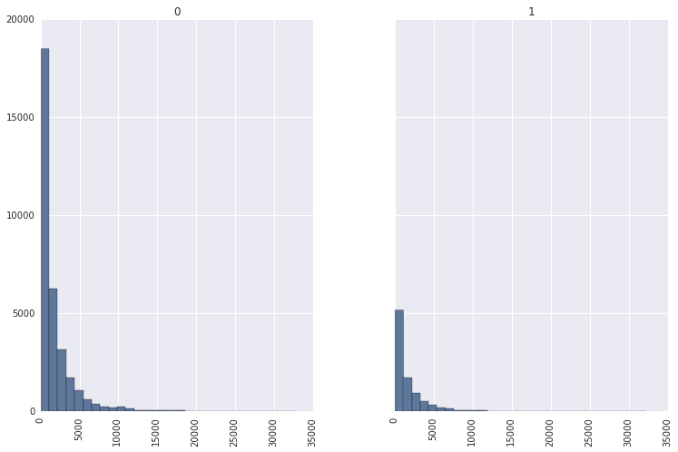

```python
#subway.ENTRIESn_hourly.plot()
subway.ENTRIESn_hourly.hist(by = subway.rain, sharey = True, bins = 30)
#plt.title('Histogram of Hourly Entries Given Rain Status')
```

Histogram of Hourly Entries Given Rain Status

```python
no_rain = subway.ENTRIESn_hourly[subway.rain == 0]
rain = subway.ENTRIESn_hourly[subway.rain == 1]
```

Welch's T-Test 2-sided Positive t-value indicates rain is greater than no rain. If we are performing a one sided test, the p value would be half.

```python
scipy.stats.ttest_ind(rain, no_rain, equal_var=False)
```

```
(5.0428827476194309, 4.6414024316324798e-07)
```

Shapiro Wilk Test for Normality

```python
#scipy.stats.shapiro(subway.ENTRIESn_hourly)
```

Mann Whitney U

```python
scipy.stats.mannwhitneyu(rain, no_rain)
```

```
(153635120.5, 2.7410695712437496e-06)
```

To address our first question, we perform both Welch's T-test and the Mann-Whitney U Rank test. Given that the data is not normally distributed, the Mann-Whitney U would be more appropriate as it is more robust. However, both of the tests return a p value of less than .05, and therefore our result is statistically significant and the probability of our data/observation given there is no difference is less than 10^-5. Our analysis showed that for each data point, there is an average of 1845 people when there is no rain, and an average of 2028 when it rains. This is a an increase of 183 on average, or approximately 10%, when it rains.

For the next portion of the project, we use linear regression to predict the number of entries at a given station at a given time based on our weather data. Our implementation of this linear regression model uses the OLS from SciKit Learn.

```python
subway.groupby(['UNIT','station']).size()
```

```
UNIT  station
R003  CYPRESS HILLS      168
R004  ELDERTS LANE       175
R005  FOREST PARKWAY     172
R006  WOODHAVEN BLVD     180
R007  104 ST             170
R008  111 ST             169
R009  121 ST             175
R011  42 ST-PA BUS TE    184
R012  34 ST-PENN STA     186
R013  34 ST-PENN STA     186
R016  LEXINGTON-53 ST    184
R017  LEXINGTON-53 ST    186
R018  ROOSEVELT AVE      185
R019  JAMAICA-179 ST     186
R020  47-50 ST-ROCK      186
R021  42 ST-BRYANT PK    184
R022  34 ST-HERALD SQ    186
R023  34 ST-HERALD SQ    186
R024  SUTPHIN BLVD       185
R025  JAMAICA CENTER     186
R027  WALL ST            186
R029  WORLD TRADE CTR    186
R030  CHAMBERS ST        186
R031  34 ST-PENN STA     186
R032  42 ST-TIMES SQ     185
R033  42 ST-TIMES SQ     186
R034  125 ST             170
R035  168 ST-BROADWAY    184
R036  DYCKMAN ST         177
R037  207 ST             183
                        ...
R321  18 ST              186
R322  SPRING ST          179
R323  110 ST-CPN         172
R325  WHITLOCK AVE       175
R330  3 AVE              177
R335  BEACH 67 ST        164
R336  BEACH 60 ST        164
R337  BEACH 44 ST        168
```

[output cut: 8 more lines]

```
R358  BEACH 25 ST        167
R370  71 ST              176
R371  79 ST              172
R372  18 AVE             169
R373  20 AVE             168
R382  GRANT AVE          177
R424  AVE P              165
R429  PELHAM BAY PARK    183
R453  23 ST-6 AVE        162
R454  PROSPECT AVE       167
R455  25 ST              168
R456  HOYT ST            177
R459  ORCHARD BEACH       88
R464  AQUEDUCT TRACK     169
dtype: int64
```

```python
subway.columns
```

```
Index([u'UNIT', u'DATEn', u'TIMEn', u'ENTRIESn', u'EXITSn', u'ENTRIESn_hourly',
       u'EXITSn_hourly', u'datetime', u'hour', u'day_week', u'weekday',
       u'station', u'latitude', u'longitude', u'conds', u'fog', u'precipi',
       u'pressurei', u'rain', u'tempi', u'wspdi', u'meanprecipi',
       u'meanpressurei', u'meantempi', u'meanwspdi', u'weather_lat',
       u'weather_lon'],
      dtype='object')
```

```python
subway.dtypes #Quick inspection of the Data Types as many are categorical/factor variables and will be need to be represented as such
```

```
UNIT                object
DATEn               object
TIMEn               object
ENTRIESn             int64
EXITSn               int64
ENTRIESn_hourly    float64
EXITSn_hourly      float64
datetime            object
hour                 int64
day_week             int64
weekday              int64
station             object
latitude           float64
longitude          float64
conds               object
fog                  int64
precipi            float64
pressurei          float64
rain                 int64
tempi              float64
wspdi              float64
meanprecipi        float64
meanpressurei      float64
meantempi          float64
meanwspdi          float64
weather_lat        float64
weather_lon        float64
dtype: object
```

```python
#import the module for split the data into training and test sets
import sklearn.cross_validation
```

Model #1: No Weather Features

```python
features_base = subway[['weekday']] ##Weekday is a binary variable
values = subway[['ENTRIESn_hourly']]

dummy_hour = pd.get_dummies(subway['hour'], prefix = 'hour') #Hourly is changed to a categorical variable
features_base = features_base.join(dummy_hour)

dummy_units = pd.get_dummies(subway['UNIT'], prefix = 'unit')
features_base = features_base.join(dummy_units)

dummy_day = pd.get_dummies(subway['day_week'], prefix = 'day')
features_base = features_base.join(dummy_day)

features_array = features_base.values
values_array = values.values

features_array_train, features_array_test, values_array_train, values_array_test = sklearn.cross_validation.train_test_split(features_array, values_array, random_state = 1)

print "Size of Training Data:",
print features_array_train.size
print "Size of Test Data:",
print features_array_test.size

model_base = sklearn.linear_model.LinearRegression()
model_base.fit(features_array_train, values_array_train)

print "Training Data Accuracy:",
print (model_base.score(features_array_train, values_array_train))
print "Test Data Accuracy:",
print (model_base.score(features_array_test, values_array_test))
```

```
Size of Training Data: 8124444
Size of Test Data: 2708402
Training Data Accuracy: 0.541930544907
Test Data Accuracy: 0.545766420927
```

Model #2: Only Weather Features

```python
features_weather = subway[['rain', 'precipi', 'fog', 'meantempi']]
values = subway[['ENTRIESn_hourly']]

features_array = features_weather.values
values_array = values.values

features_array_train, features_array_test, values_array_train, values_array_test = sklearn.cross_validation.train_test_split(features_array, values_array, random_state = 1)

model_base = sklearn.linear_model.LinearRegression()
model_base.fit(features_array_train, values_array_train)

print "Training Data Accuracy:",
print (model_base.score(features_array_train, values_array_train))
print "Test Data Accuracy:",
print (model_base.score(features_array_test, values_array_test))
```

```
Training Data Accuracy: 0.00266751349568
Test Data Accuracy: 0.00205681753579
```

Model#3: All Relevant Features

```python
features_weather = subway[['rain', 'precipi', 'fog', 'meantempi', 'weekday']]
values = subway[['ENTRIESn_hourly']]

dummy_hour = pd.get_dummies(subway['hour'], prefix = 'hour')
features_weather = features_weather.join(dummy_hour)

dummy_units = pd.get_dummies(subway['UNIT'], prefix = 'unit')
features_weather = features_weather.join(dummy_units)

dummy_day = pd.get_dummies(subway['day_week'], prefix = 'day')
features_weather = features_weather.join(dummy_day)

dummy_conds = pd.get_dummies(subway['conds'], prefix = 'condition')
features_weather = features_weather.join(dummy_conds)

features_array = features_weather.values
values_array = values.values

features_array_train, features_array_test, values_array_train, values_array_test = sklearn.cross_validation.train_test_split(features_array, values_array, random_state = 1)

model_base = sklearn.linear_model.LinearRegression()
model_base.fit(features_array_train, values_array_train)

print "Training Data Accuracy:",
print (model_base.score(features_array_train, values_array_train))
print "Test Data Accuracy:",
print (model_base.score(features_array_test, values_array_test))
```

```
Training Data Accuracy: 0.545830149162
Test Data Accuracy: 0.54915152211
```

```python
#print "Model Coefficient:",
#print model_base.intercept_
#print zip(list(features_weather.columns),model_base.coef_[0])
```

After training our model, we should that it returns an R^2 value of .544 using online a baseline prediction and .548 when incorporating weather information. These values suggest that best predictors for hourly subway ridership are factors such as the station and the time (hour and day). The addition of weather information provides a very slight increase in our ability to predict ridership, but the data alone does not provide much insight. Intuitively, this is reasonable, as stations in more high traffic or densely populated areas would generally have more riders. In addition, most of the traffic would also occur during the day when people are active. Lastly, we would expect to see that weekdays and weekends have different traffic patterns.

# Visualizations

Looking at the heatmaps, we can see that the relationship between these three predictors may not be linear. In particular, we can see that at many of the stations, the increase in the number of people given a day or time is not constant. For instance, some stations may increase by a couple thousand given the day while others increase by ten thousand.

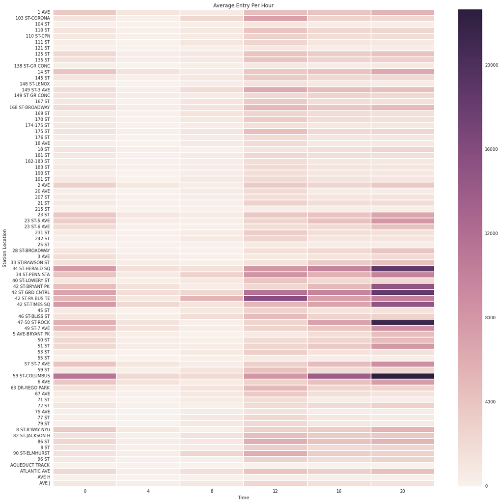

```python
subway_station_hour = pd.pivot_table(subway, values = 'ENTRIESn_hourly', index = ['station'], columns=['hour'])
#subway_station_hour.head(30)

plt.figure(figsize=(20,20))

sns.heatmap(subway_station_hour.head(80)) #Heatmap for subset of data

plt.title('Average Entry Per Hour')
plt.xlabel('Time')
plt.ylabel('Station Location')

#print subway_station_hour
```

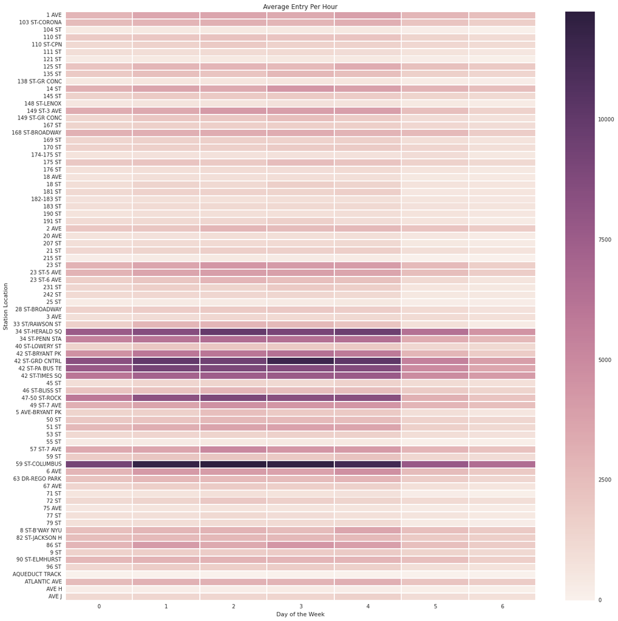

```python
subway_station_day = pd.pivot_table(subway, values = 'ENTRIESn_hourly', index = ['station'], columns=['day_week'])
#subway_station_hour.head(30)

plt.figure(figsize=(20,20))

sns.heatmap(subway_station_day.head(80)) #Heatmap for subset of data
plt.title('Average Entry Per Hour')
plt.xlabel('Day of the Week')
plt.ylabel('Station Location')

#print subway_station_hour
```

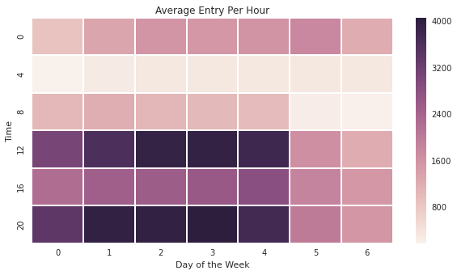

```python
subway_day_hour = pd.pivot_table(subway, values = 'ENTRIESn_hourly', index = ['hour'], columns=['day_week'])
#subway_station_hour.head(30)

plt.figure(figsize=(10,5))

sns.heatmap(subway_day_hour) #Heatmap for subset of data
plt.title('Average Entry Per Hour')
plt.xlabel('Day of the Week')
plt.ylabel('Time')

#print subway_station_hour
```

This particular approach does give us some predictive power in determining the entries/hour given our parameters. However, it is possible that the model can be improved using other methods, such as K-nearest neighbor. In particular, this model assumes a linear fit to the data, that may not exist. Specifically, it assumes that variables such as station, the day of the week, and time are all independent, which is not as there may be interactions between the these factors that are not taken into account in our model.

```python
#ggplot(aes('ENTRIESn_hourly', color = 'rain'), data = subway) + geom_histogram() #Broken in current version of ggplot/pandas?
```

```python
#ggplot(aes('hour', 'ENTRIESn_hourly', color = 'rain'), data = subway) + geom_jitter(alpha =.1) + xlab('Hour') + ylab('Entries Per Hour')
```

```python
#ggplot(aes('station', 'ENTRIESn_hourly', color = 'rain'), data = subway) + geom_point(alpha =.1)
```

```python
#ggplot(aes('ENTRIESn_hourly', fill = 'rain'), data = subway) + geom_histogram(binwidth = 1000)
```

# Boxplots using Rain Status, Station, Day or Time as Predictors

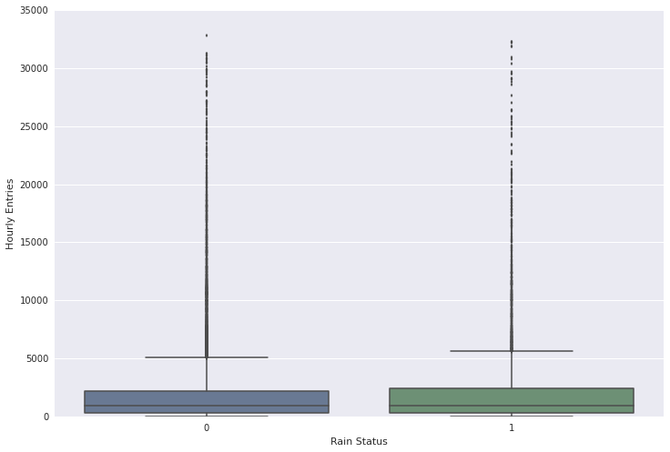

```python
sns.boxplot(subway.ENTRIESn_hourly, groupby = subway.rain)
#plt.title('Hourly Entries')
plt.xlabel('Rain Status')
plt.ylabel('Hourly Entries')
```

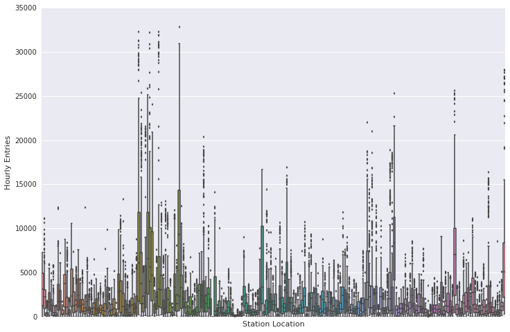

```python
sns.boxplot(subway.ENTRIESn_hourly, groupby = subway.station)
plt.gca().xaxis.set_major_locator(plt.NullLocator())
plt.xlabel('Station Location')
plt.ylabel('Hourly Entries')
```

This figure provides us with the distribution of hourly entries for a given station. The axis has been removed as it does not fit well.

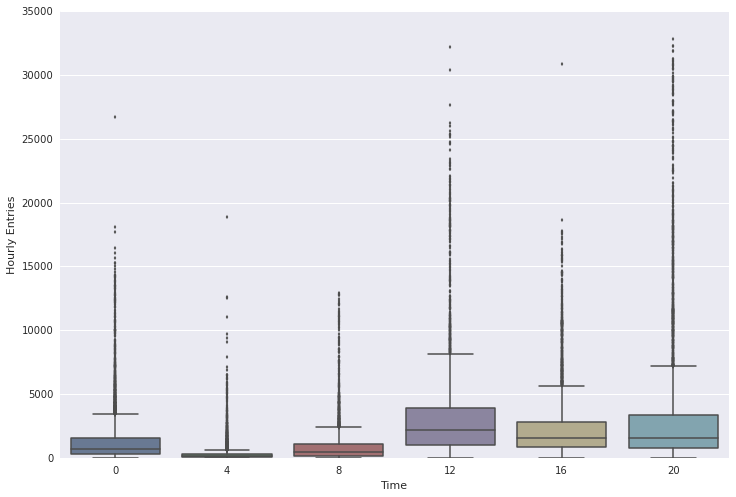

```python
sns.boxplot(subway.ENTRIESn_hourly, groupby = subway.hour)
plt.xlabel('Time')
plt.ylabel('Hourly Entries')
```

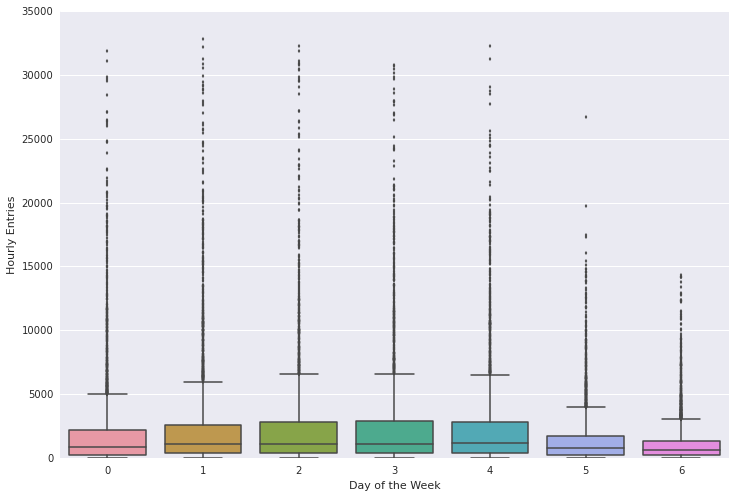

```python
sns.boxplot(subway.ENTRIESn_hourly, groupby = subway.day_week)
plt.xlabel('Day of the Week')
plt.ylabel('Hourly Entries')
```

# Scatter Plots with Regression Line

As part of our visualizations, we also conduct a few visualizations on the weather variables that are interested in. As we can see from the plots below, when using either rain, precipitation, fog, mean temperature. For many of these weather predictors, the slope of the linear regression line is fairly close to 0, suggesting that none of these is a particularly good predictors. Interestingly, precipitation appears to have a slight negative slope. Weekday appears to have a positive slope, as we would guess from looking at the effects on the day on subway ridership. However, we would need another statistical test to compare the difference between all of the days of the week, since they are categorical variables.

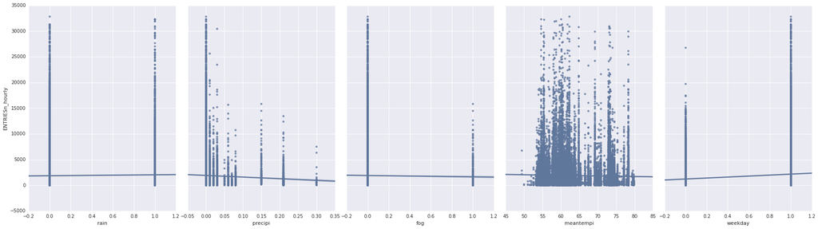

```python
sns.pairplot(subway, x_vars = ['rain', 'precipi', 'fog', 'meantempi', 'weekday'], y_vars = 'ENTRIESn_hourly', size = 7, aspect=.7, kind = 'reg')
```

```python
subway_station_hour.head(30)
```

| hour station | 0 | 4 | 8 | 12 | 16 | 20 |
| --- | --- | --- | --- | --- | --- | --- |
| 1 AVE | 3525.387097 | 1061.451613 | 655.700000 | 4421.548387 | 3938.354839 | 5370.000000 |
| 103 ST-CORONA | 1203.870968 | 252.225806 | 2278.888889 | 6924.806452 | 2666.129032 | 2220.612903 |
| 104 ST | 137.516129 | 35.677419 | 324.875000 | 1045.774194 | 412.645161 | 306.233333 |
| 110 ST | 1117.354839 | 192.064516 | 845.750000 | 3919.129032 | 2352.193548 | 2474.935484 |
| 110 ST-CPN | 884.566667 | 182.800000 | 633.631579 | 2809.677419 | 1757.612903 | 1826.193548 |
| 111 ST | 346.645161 | 76.258065 | 979.300000 | 2414.129032 | 982.868852 | 743.951613 |
| 121 ST | 168.774194 | 65.096774 | 215.409091 | 713.700000 | 381.366667 | 434.741935 |
| 125 ST | 2275.322581 | 415.754098 | 903.240000 | 4046.933333 | 3303.901639 | 4020.532258 |
| 135 ST | 1544.709677 | 368.645161 | 752.400000 | 4007.677419 | 2738.387097 | 2939.774194 |
| 138 ST-GR CONC | 265.516129 | 61.419355 | 336.923077 | 847.633333 | 581.966667 | 744.548387 |
| 14 ST | 4051.645161 | 1281.806452 | 702.741935 | 3629.870968 | 4206.838710 | 6409.903226 |
| 145 ST | 1146.644444 | 190.454545 | 815.306667 | 3378.494382 | 2185.125000 | 2114.840909 |
| 148 ST-LENOX | 224.870968 | 46.032258 | 357.000000 | 1335.129032 | 749.322581 | 583.000000 |
| 149 ST-3 AVE | 1712.161290 | 280.193548 | 1867.655172 | 6293.290323 | 4684.161290 | 4353.806452 |
| 149 ST-GR CONC | 1334.033333 | 464.000000 | 615.357143 | 2248.032258 | 2568.870968 | 2260.483871 |
| 167 ST | 802.290323 | 136.564516 | 1139.159091 | 3427.770492 | 1759.816667 | 1559.887097 |
| 168 ST-BROADWAY | 1893.806452 | 366.161290 | 1286.517241 | 4881.451613 | 3689.419355 | 4773.838710 |
| 169 ST | 574.967742 | 113.935484 | 1199.645161 | 2550.000000 | 1874.935484 | 1577.419355 |
| 170 ST | 901.354839 | 152.290323 | 967.428571 | 3352.000000 | 1907.000000 | 1515.566667 |
| 174-175 ST | 802.275862 | 73.655172 | 407.206897 | 1505.172414 | 847.678571 | 909.392857 |
| 175 ST | 1200.838710 | 240.935484 | 1065.806452 | 4381.741935 | 2139.741935 | 2417.806452 |
| 176 ST | 586.935484 | 79.967742 | 601.333333 | 1978.000000 | 1008.034483 | 989.933333 |
| 18 AVE | 290.112903 | 42.852459 | 690.550000 | 1927.258065 | 739.114754 | 763.409836 |
| 18 ST | 1113.419355 | 340.419355 | 97.806452 | 1183.000000 | 1667.935484 | 2407.290323 |
| 181 ST | 820.592593 | 100.178571 | 535.421053 | 2209.321429 | 1666.333333 | 1535.481481 |
| 182-183 ST | 457.193548 | 89.838710 | 525.176471 | 1805.366667 | 914.551724 | 804.580645 |
| 183 ST | 764.666667 | 260.387097 | 521.250000 | 2100.032258 | 1153.733333 | 1068.903226 |
| 190 ST | 336.500000 | 42.310345 | 497.200000 | 1779.925926 | 1038.533333 | 932.741935 |
| 191 ST | 761.580645 | 60.129032 | 773.272727 | 2103.551724 | 1365.827586 | 1081.700000 |
| 2 AVE | 2901.516129 | 938.774194 | 369.387097 | 3397.870968 | 2494.096774 | 3532.645161 |

```python
print subway.mean()
print ''
print subway.groupby(['rain']).aggregate(np.mean)
```

```
ENTRIESn           28124856.263242
EXITSn             19869932.521607
ENTRIESn_hourly        1886.589955
EXITSn_hourly          1361.487866
hour                     10.046754
day_week                  2.905719
weekday                   0.714436
latitude                 40.724647
longitude               -73.940364
fog                       0.009824
precipi                   0.004618
pressurei                29.971096
rain                      0.224741
tempi                    63.103780
wspdi                     6.927872
meanprecipi               0.004618
meanpressurei            29.971096
meantempi                63.103780
meanwspdi                 6.927872
weather_lat              40.728555
weather_lon             -73.938693
dtype: float64

             ENTRIESn           EXITSn  ENTRIESn_hourly  EXITSn_hourly  \
rain
0     28158345.474050  19906411.104767      1845.539439    1333.111451
1     28009333.335107  19744097.584351      2028.196035    1459.373918

           hour  day_week   weekday   latitude  longitude       fog   precipi  \
rain
0     10.049359  2.998064  0.682616  40.724497 -73.940368  0.002147  0.000008
1     10.037767  2.587167  0.824204  40.725167 -73.940349  0.036307  0.020520

      pressurei      tempi     wspdi  meanprecipi  meanpressurei  meantempi  \
rain
0     29.997082  64.304694  6.561112     0.000008      29.997082  64.304694
1     29.881459  58.961158  8.193031     0.020520      29.881459  58.961158

      meanwspdi  weather_lat  weather_lon
rain
0      6.561112    40.728433   -73.938697
1      8.193031    40.728978   -73.938680
```

# Final Model by Combining Station and Hour

```python
subway['placetime'] = subway.UNIT + ' ' + subway.hour.astype('str')
subway.columns
subway['placetime'].head()
```

```
0     R003 0
1     R003 4
2    R003 12
3    R003 16
4    R003 20
Name: placetime, dtype: object
```

```python
features_weather = subway[['rain', 'precipi', 'fog', 'meantempi', 'weekday']]


dummy_day = pd.get_dummies(subway['day_week'], prefix = 'day')
features_weather = features_weather.join(dummy_day)

dummy_pdt = pd.get_dummies(subway['placetime'], prefix = 'pdt')
features_weather = features_weather.join(dummy_pdt)

features_array = features_weather.values
values_array = subway.ENTRIESn_hourly.values

lm = sklearn.linear_model.LinearRegression()
lm.fit(features_array, values_array)
lm.score(features_array,values_array)
```

```
0.81541443249042789
```

In our analysis, we provide evidence that on days where it rains, there is an slight increase in the number of individuals who ride the subway. This is based on Mann-Whitney U Test performed on the data. Despite being statistically significant, this information provides a limited amount of information about overall subway ridership.

Our assessment of the data shows that the weather does affect the number of individuals who travel on the subway. To better understand the affects of weather on subway ridership, we use information about the station, the time, and the weather data from the subway data to generate a model. Based on our analysis, the addition of addition weather features provides only marginal gains to our model. Thus we can conclude that although weather does play a role, the number of individuals that use the subway at a given place and time are largely independent of the weather.

```python
subway.head()
```

|  | UNIT | DATEn | TIMEn | ENTRIESn | EXITSn | ENTRIESn_hourly | EXITSn_hourly | datetime | hour | day_week | weekday | station | latitude | longitude | conds | fog | precipi | pressurei | rain | tempi | wspdi | meanprecipi | meanpressurei | meantempi | meanwspdi | weather_lat | weather_lon | placetime |
| --- | --- | --- | --- | --- | --- | --- | --- | --- | --- | --- | --- | --- | --- | --- | --- | --- | --- | --- | --- | --- | --- | --- | --- | --- | --- | --- | --- | --- |
| 0 | R003 | 05-01-11 | 00:00:00 | 4388333 | 2911002 | 0 | 0 | 2011-05-01 00:00:00 | 0 | 6 | 0 | CYPRESS HILLS | 40.689945 | -73.872564 | Clear | 0 | 0 | 30.22 | 0 | 55.9 | 3.5 | 0 | 30.258 | 55.98 | 7.86 | 40.700348 | -73.887177 | R003 0 |
| 1 | R003 | 05-01-11 | 04:00:00 | 4388333 | 2911002 | 0 | 0 | 2011-05-01 04:00:00 | 4 | 6 | 0 | CYPRESS HILLS | 40.689945 | -73.872564 | Partly Cloudy | 0 | 0 | 30.25 | 0 | 52.0 | 3.5 | 0 | 30.258 | 55.98 | 7.86 | 40.700348 | -73.887177 | R003 4 |
| 2 | R003 | 05-01-11 | 12:00:00 | 4388333 | 2911002 | 0 | 0 | 2011-05-01 12:00:00 | 12 | 6 | 0 | CYPRESS HILLS | 40.689945 | -73.872564 | Mostly Cloudy | 0 | 0 | 30.28 | 0 | 62.1 | 6.9 | 0 | 30.258 | 55.98 | 7.86 | 40.700348 | -73.887177 | R003 12 |
| 3 | R003 | 05-01-11 | 16:00:00 | 4388333 | 2911002 | 0 | 0 | 2011-05-01 16:00:00 | 16 | 6 | 0 | CYPRESS HILLS | 40.689945 | -73.872564 | Mostly Cloudy | 0 | 0 | 30.26 | 0 | 57.9 | 15.0 | 0 | 30.258 | 55.98 | 7.86 | 40.700348 | -73.887177 | R003 16 |
| 4 | R003 | 05-01-11 | 20:00:00 | 4388333 | 2911002 | 0 | 0 | 2011-05-01 20:00:00 | 20 | 6 | 0 | CYPRESS HILLS | 40.689945 | -73.872564 | Mostly Cloudy | 0 | 0 | 30.28 | 0 | 52.0 | 10.4 | 0 | 30.258 | 55.98 | 7.86 | 40.700348 | -73.887177 | R003 20 |

```python
subway.tail()
```

|  | UNIT | DATEn | TIMEn | ENTRIESn | EXITSn | ENTRIESn_hourly | EXITSn_hourly | datetime | hour | day_week | weekday | station | latitude | longitude | conds | fog | precipi | pressurei | rain | tempi | wspdi | meanprecipi | meanpressurei | meantempi | meanwspdi | weather_lat | weather_lon | placetime |
| --- | --- | --- | --- | --- | --- | --- | --- | --- | --- | --- | --- | --- | --- | --- | --- | --- | --- | --- | --- | --- | --- | --- | --- | --- | --- | --- | --- | --- |
| 42644 | R464 | 05-31-11 | 04:00:00 | 567311 | 132804 | 0 | 0 | 2011-05-31 04:00:00 | 4 | 1 | 1 | AQUEDUCT TRACK | 40.668221 | -73.834026 | Partly Cloudy | 0 | 0 | 30.14 | 0 | 73.0 | 6.9 | 0 | 30.168333 | 75.366667 | 7.1 | 40.660004 | -73.844849 | R464 4 |
| 42645 | R464 | 05-31-11 | 08:00:00 | 290767 | 59788 | 0 | 0 | 2011-05-31 08:00:00 | 8 | 1 | 1 | AQUEDUCT TRACK | 40.668221 | -73.834026 | Clear | 0 | 0 | 30.19 | 0 | 80.1 | 6.9 | 0 | 30.168333 | 75.366667 | 7.1 | 40.660004 | -73.844849 | R464 8 |
| 42646 | R464 | 05-31-11 | 12:00:00 | 419894 | 95280 | 0 | 0 | 2011-05-31 12:00:00 | 12 | 1 | 1 | AQUEDUCT TRACK | 40.668221 | -73.834026 | Clear | 0 | 0 | 30.20 | 0 | 81.0 | 10.4 | 0 | 30.168333 | 75.366667 | 7.1 | 40.660004 | -73.844849 | R464 12 |
| 42647 | R464 | 05-31-11 | 16:00:00 | 419894 | 95280 | 0 | 0 | 2011-05-31 16:00:00 | 16 | 1 | 1 | AQUEDUCT TRACK | 40.668221 | -73.834026 | Clear | 0 | 0 | 30.17 | 0 | 77.0 | 13.8 | 0 | 30.168333 | 75.366667 | 7.1 | 40.660004 | -73.844849 | R464 16 |
| 42648 | R464 | 05-31-11 | 20:00:00 | 419894 | 95280 | 0 | 0 | 2011-05-31 20:00:00 | 20 | 1 | 1 | AQUEDUCT TRACK | 40.668221 | -73.834026 | Clear | 0 | 0 | 30.18 | 0 | 69.1 | 4.6 | 0 | 30.168333 | 75.366667 | 7.1 | 40.660004 | -73.844849 | R464 20 |

# Reflection

Together with the remaining features, I generated a linear model with an R^2 value of .815, which is significantly better than the previous ones. This may be caused by interactions between available features. In light of this, it may be plausible to simply use the conditional mean of entries/hour given station, date, and time to predict subway ridership given a set of predictors.